# Differentially Methylated CpG Positions in Vapers vs. Non-vapers

[figure not shown]

# Introduction

The purpose of this report is to document the steps taken and the subsequent results for the Differentially Methylated Position (DMP) analysis as part of the Adolescent Vaping study.

# Methods

Up to this point, the data has been normalized using Noob, BMIQ, and RUVm. To find differentially methylated positions (DMPs), a linear model will be fit for each CpG site that remains after pre-processing and corrected using False Discovery Rate (FDR).

The same model as the RUV-Seq Analysis will be fit to maintain comparability for any future integrative analyses. The model will look for changes in M-values due to vape status after adjusting for age, sex, recruitment center and two RUV-factors:

$$M-Value = \beta_0 + \beta_1 * vape \
status + \beta_2 * center + \beta_3* sex + \beta_4 * age + \beta_5 *
ruv_{k1} + \beta_6 * ruv_{k2} + \epsilon_i$$

The ‘methylation_interim_results_yyyy_mm_dd’ report documented problems with model specification. Specifically, issues caused by collinearity between Vape Status, the exposure of interest, and recruitment center. This report will pose two solutions to the model specification issues found in that report. The first solution is to drop recruitment center from the model. The other is to use the method proposed by Iterson, et. al. to control for ‘deflated’ p-values<sup>1</sup>. The analysis will compare results from the two methods and conclude with a decision about which results to refer to moving forward.

# Descriptive Statistics

Before continuing to results, it is important to first re-assess the distribution of demographics in the study. Specifically, there is one study participant (SID: 102, RNA_ID: Sample 12) who had a complete RNA-Seq data who was not included in the methylation array. This subject was a *vaping* *male* from *Pueblo, CO*.

```r
library(arsenal)
clin_metadata <- read_csv(here("DataProcessed/clinical_metadata/master_clinical_metadata_2022_09_02.csv"), show_col_types = F)

clin_metadata <- clin_metadata %>%
  filter(!is.na(methylation_id),
         !is.na(vape_6mo_lab))
#create table 1
vape_6mo_table1 <- clin_metadata %>%
  tableby(vape_6mo_lab ~ sex_lab + age + recruitment_center +
            latino_lab + fev1 + fev1_fvc +
            r5 + x20, data = ., digits = 1, test = T)

#Fix Labels
arsenal::labels(vape_6mo_table1) <- c(vape_6mo_lab = "Vaped in last 6 months",
                             age = "Age (yrs)", sex_lab = "Sex",
                             recruitment_center = "Recruitment Center",
                             latino_lab = "Ethnicity", fev1 = 'FEV1',
                             fev1_fvc = "FEV1/FVC (%)", r5 = 'R5', x20 = 'X20')

#Print Tables
summary(vape_6mo_table1, pfootnote = T, title="Table 1: Distribution of demographic variables for the subjects included in the methylation analysis. A test for association with vape status is included for each variable.")
```

Table 1: Distribution of demographic variables for the subjects included in the methylation analysis. A test for association with vape status is included for each variable.

|  | Did Not Vape in Last 6 Months (N=36) | Vaped in Last 6 Months (N=11) | Total (N=47) | p value |
| --- | --- | --- | --- | --- |
| **Sex** |  |  |  | 0.138<sup>1</sup> |
| Female | 17 (47.2%) | 8 (72.7%) | 25 (53.2%) |  |
| Male | 19 (52.8%) | 3 (27.3%) | 22 (46.8%) |  |
| **Age (yrs)** |  |  |  | 0.644<sup>2</sup> |
| Mean (SD) | 14.6 (1.4) | 14.8 (1.5) | 14.6 (1.5) |  |
| Range | 12.0 - 17.0 | 13.0 - 17.0 | 12.0 - 17.0 |  |
| **Recruitment Center** |  |  |  | < 0.001<sup>1</sup> |
| Aurora | 14 (38.9%) | 0 (0.0%) | 14 (29.8%) |  |
| CommCity/Denver | 13 (36.1%) | 1 (9.1%) | 14 (29.8%) |  |
| Pueblo | 9 (25.0%) | 10 (90.9%) | 19 (40.4%) |  |
| **Ethnicity** |  |  |  | 0.086<sup>1</sup> |
| LatinX | 23 (63.9%) | 10 (90.9%) | 33 (70.2%) |  |
| Non-LatinX | 13 (36.1%) | 1 (9.1%) | 14 (29.8%) |  |
| **FEV1** |  |  |  | 0.076<sup>2</sup> |
| N-Miss | 10 | 10 | 20 |  |
| Mean (SD) | 2.6 (0.7) | 3.9 (NA) | 2.6 (0.7) |  |
| Range | 1.2 - 3.9 | 3.9 - 3.9 | 1.2 - 3.9 |  |
| **FEV1/FVC (%)** |  |  |  | 0.505<sup>2</sup> |
| N-Miss | 10 | 10 | 20 |  |
| Mean (SD) | 0.8 (0.1) | 0.7 (NA) | 0.8 (0.1) |  |
| Range | 0.5 - 1.0 | 0.7 - 0.7 | 0.5 - 1.0 |  |
| **R5** |  |  |  | 0.018<sup>2</sup> |
| N-Miss | 1 | 0 | 1 |  |
| Mean (SD) | 4.0 (0.9) | 4.9 (1.2) | 4.2 (1.1) |  |
| Range | 2.0 - 6.1 | 3.7 - 7.6 | 2.0 - 7.6 |  |
| **X20** |  |  |  | < 0.001<sup>2</sup> |
| N-Miss | 4 | 2 | 6 |  |
| Mean (SD) | 0.1 (0.6) | 1.0 (0.7) | 0.3 (0.7) |  |
| Range | -1.1 - 2.4 | -0.3 - 2.3 | -1.1 - 2.4 |  |

1. Pearson’s Chi-squared test
2. Linear Model ANOVA

Table 1 shows a decrease from N = 12 to N = 11 vapers in comparison with the RNA-Seq analysis. Additionally, *Recruitment Center*, *R5*, and *X20* are are all significantly associated with *Vape Status*. This is consistent with the RNA-Seq analysis.

# Results

The “methylation_interim_results” document the issue of model misspecification. The problem may be summarized by looking at p-value distributions for models which test varying combinations of covariates. All of the models below adjust for vape status, age, and sex. The sub-title of each figure documents the additional covariates added to the model which produced the corresponding p-value distribution.

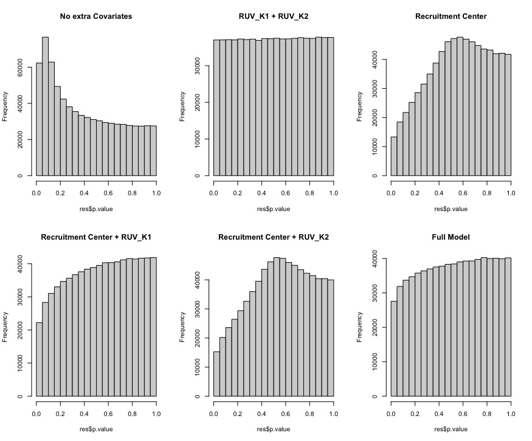

Figure 1: P-value distribution for all pairwise models with recruitment center and the two ruv factors as covariates

The models show an anti-conservative distribution of p-values when adjusting for no covariates, and a uniform distribution when accounting only for the two latent factors (RUV_K1 + RUV_K2). The models show a trend of deflated p-values whenever recruitment center is included in the model. In summary, it appears that the collinearity between recruitment center and and vape status is driving the pattern of deflated p-values seen in the ‘Full Model’.

We will report the results from two models which pose solutions to the problem of deflated p-values. The first solution is to exclude recruitment center from the model as seen in Figure 1 (plot ‘RUV_K1 + RUV_K2’). We will refer to this as the **no center** model. The other solution is to attempt to control for the deflation using Bayesian methods to estimate potential inflation and bias in the p-value distribution<sup>1</sup>. We will refer to this as the **bacon** model.

*Fig. 2* shows p-value distribtions for the two proposed models. The *no center* model shows no biological signal, while the *Bacon* model shows a slight peak near 0.

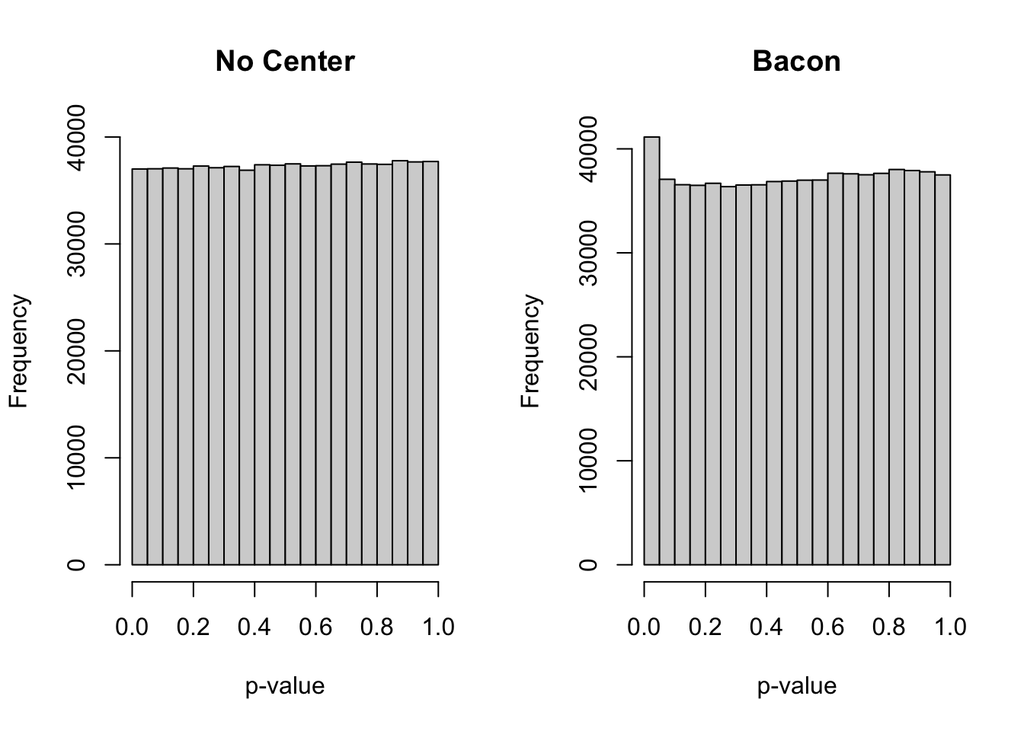

P-value distributions for the two proposed models.

```r
# Read in the results -----------------------------------------------------


full_res <- read_csv(here("DataProcessed/methylation/results/results_ruvk1_ruvk2.csv"))


# run bacon ---------------------------------------------------------------

bc <- bacon(teststatistics = full_res$`t value`,
            standarderrors = full_res$`Std. Error`)

## bacon inflation factor
bc_inflation <- inflation(bc)

## bacon bias
bc_bias <- bias(bc)

## bacon-corrected pvals
pvals.corr <- pval(bc)

full_res$pval.bacon <- as.vector(pvals.corr)
full_res$fdr.bacon <- p.adjust(full_res$pval.bacon, method = "fdr")

# Pick out desired results
bacon_res <- full_res %>%
  select(CpG_Site, Estimate, `Std. Error`, pval.bacon, fdr.bacon) %>%
  rename(pval = pval.bacon,
         fdr = fdr.bacon)

no_center_res <- read_csv(here("DataProcessed/methylation/results/noCenter_res_2022_12_01.csv"))

#bacon_res <- read_csv(here("DataProcessed/methylation/results/full_res_bacon_2022_12_01.csv"))

noCenter_sig <- no_center_res[no_center_res$fdr < 0.05,]
bacon_sig <- bacon_res[bacon_res$fdr < 0.05, ]

par(mfrow = c(1, 2))
hist(no_center_res$p.value, main = "No Center",
     xlab = "p-value",
     ylim = c(0,40000))
hist(bacon_res$pval, main = "Bacon", xlab = "p-value")
```

The model using the bacon correction returned 13 significant CpG Sites while the No Center model returned 0 significant CpG sites. Table 2 shows the significant CpG Sites returned by the bacon-corrected model and how those sites rank in the No Center model.

```r
no_center_res <- no_center_res %>%
  arrange(p.value) %>%
  mutate(Rank = seq(1, length(p.value), 1),
         p.value = if_else(p.value < 0.001, "< 0.001", as.character(round(p.value, 3))),
         fdr = round(fdr, 3)) %>%
  select(CpG_Site, Estimate, `Std. Error`, p.value, fdr, Rank)

bacon_res <- bacon_res %>%
  arrange(pval) %>%
  mutate(Rank = seq(1, length(pval), 1),
         pval = if_else(pval < 0.001, '< 0.001', as.character(round(pval, 3)))) %>%
  select(CpG_Site, Estimate, `Std. Error`, pval, fdr, Rank)

all_res <- left_join(bacon_res, no_center_res, by = "CpG_Site", suffix = c(".bacon", ".noCenter"))

all_res_sig <- all_res[all_res$fdr.bacon < 0.05,]

gt_tbl <- all_res %>%
  filter(fdr.bacon < 0.05) %>%
  gt() %>%
  tab_header(title = "Table 2: Significant Bacon Results Compared to No Center Results") %>%
  tab_spanner(label = "Bacon",
              columns = c(Estimate.bacon, `Std. Error.bacon`, pval, fdr.bacon, Rank.bacon)) %>%
  tab_spanner(label = "No Center",
              columns = c(Estimate.noCenter, `Std. Error.noCenter`, p.value, fdr.noCenter, Rank.noCenter)) %>%
  fmt_number(columns = c(Estimate.bacon, `Std. Error.bacon`, Estimate.noCenter, `Std. Error.noCenter`),
             decimals = 3) %>%
  cols_label(CpG_Site = 'CpG Site',
             Estimate.bacon = 'Estimate',
             `Std. Error.bacon` = 'Std. Error',
             pval = "p-value",
             fdr.bacon = "FDR",
             Rank.bacon = "Rank",
             Estimate.noCenter = "Estimate",
             `Std. Error.noCenter` = "Std. Error",
             p.value = "p-value",
             fdr.noCenter = "FDR",
             Rank.noCenter = "Rank")
gt_tbl
```

Table 2: Significant Bacon Results Compared to No Center Results

| CpG Site | Bacon Estimate | Bacon Std. Error | Bacon p-value | Bacon FDR | Bacon Rank | No Center Estimate | No Center Std. Error | No Center p-value | No Center FDR | No Center Rank |
| --- | --- | --- | --- | --- | --- | --- | --- | --- | --- | --- |
| cg14743902 | −0.306 | 0.048 | < 0.001 | 1.500204e-05 | 1 | −0.193 | 0.052 | < 0.001 | 1.000 | 401 |
| cg15321238 | −0.285 | 0.055 | < 0.001 | 1.096025e-02 | 2 | −0.241 | 0.052 | < 0.001 | 1.000 | 21 |
| cg02123174 | −0.346 | 0.066 | < 0.001 | 1.096025e-02 | 3 | −0.298 | 0.058 | < 0.001 | 0.904 | 6 |
| cg23124148 | −0.360 | 0.069 | < 0.001 | 1.096025e-02 | 4 | −0.280 | 0.066 | < 0.001 | 1.000 | 84 |
| cg26967868 | 0.294 | 0.063 | < 0.001 | 4.657084e-02 | 5 | 0.224 | 0.058 | < 0.001 | 1.000 | 263 |
| cg06238287 | −0.212 | 0.043 | < 0.001 | 4.657084e-02 | 6 | −0.212 | 0.040 | < 0.001 | 0.675 | 2 |
| cg17892555 | −0.227 | 0.047 | < 0.001 | 4.657084e-02 | 7 | −0.216 | 0.040 | < 0.001 | 0.675 | 3 |
| cg04713912 | −0.225 | 0.047 | < 0.001 | 4.657084e-02 | 8 | −0.168 | 0.044 | < 0.001 | 1.000 | 271 |
| cg11903190 | 0.254 | 0.056 | < 0.001 | 4.657084e-02 | 9 | 0.256 | 0.048 | < 0.001 | 0.675 | 5 |
| cg20591652 | −0.280 | 0.059 | < 0.001 | 4.657084e-02 | 10 | −0.200 | 0.059 | 0.002 | 1.000 | 1045 |
| cg15824056 | −0.678 | 0.142 | < 0.001 | 4.657084e-02 | 11 | −0.484 | 0.135 | < 0.001 | 1.000 | 595 |
| cg17935347 | 0.240 | 0.054 | < 0.001 | 4.997174e-02 | 12 | 0.252 | 0.048 | < 0.001 | 0.675 | 4 |
| cg14309384 | −0.403 | 0.085 | < 0.001 | 4.997174e-02 | 13 | −0.320 | 0.077 | < 0.001 | 1.000 | 111 |

Of the significant CpG Site returned by the Bacon model, only 5 remain in the top 10 in the **No Center** model.

**Fig. 3** shows estimates for both the Bacon model and the No Center model and how the estimates change across the model. The red diagonal line indicates equivalent estimates.

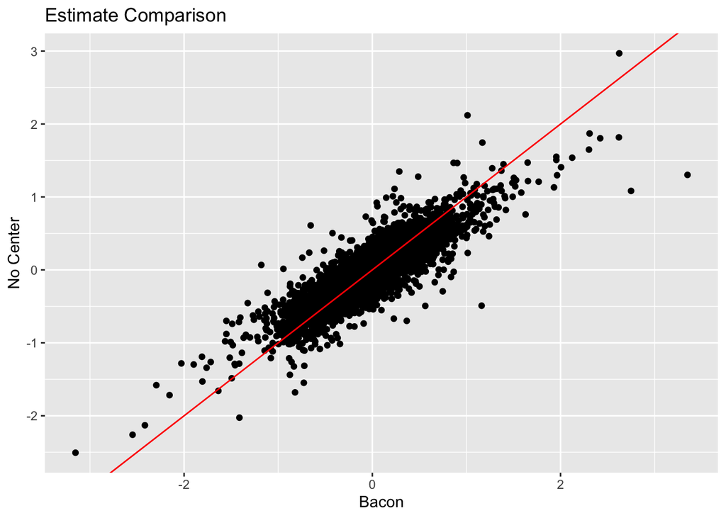

```r
all_res %>%
  ggplot(aes(x = Estimate.bacon, y = Estimate.noCenter)) +
  geom_point()+
  geom_abline(slope = 1,
              intercept = 0,
              col = 'red')+
  labs(y = "No Center",
       x = "Bacon",
       title = "Estimate Comparison")
```

# Conclusion

There were two solutions proposed for the problem of deflated p-values presented by the full model. In summary, the model which did not adjust for the effects of recruitment center found no biological signal, while the model which used the bacon-adjustment found 13. We feel that we should be skeptical of these significant sites due to low statistical power. The Differentially Methylated Region (DMR) analysis is still to come, and will have lower burden of multiple testing. Detecting broader patterns in the methylation profile may be a more reasonable expectation.

[figure not shown]

1.

Iterson M van, Zwet EW van, Heijmans BT. Controlling bias and inflation in epigenome- and transcriptome-wide association studies using the empirical null distribution. *Genome Biology*. 2017;18(1). doi:10.1186/s13059-016-1131-9.